# Titanic

2024-04-20

## Problem introduction

## Introduction

- What is the **Titanic dataset** about?
- The goal: predicting survival on Titanic passengers using classifiers and feature selection

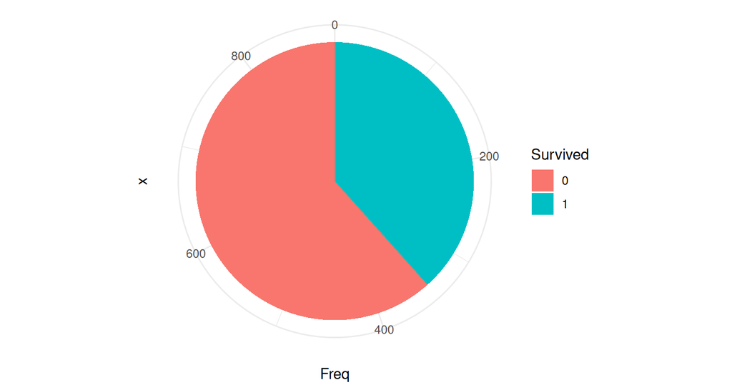

## Dataset

- Dataset structure

| PassengerId | Pclass | Sex | Age | SibSp | Parch | Cabin | Fare | Survived |
| --- | --- | --- | --- | --- | --- | --- | --- | --- |
| 1 | 3 | male | 22 | 1 | 0 |  | 7.2500 | 0 |
| 2 | 1 | female | 38 | 1 | 0 | C85 | 71.2833 | 1 |
| 3 | 3 | female | 26 | 0 | 0 |  | 7.9250 | 1 |
| 4 | 1 | female | 35 | 1 | 0 | C123 | 53.1000 | 1 |
| 5 | 3 | male | 35 | 0 | 0 |  | 8.0500 | 0 |

<sub>*Omited **Name**, **Ticket** and **Embarked** features for visual reason*</sub>

## Target

- Our target - *Survived?* (binary 0/1)

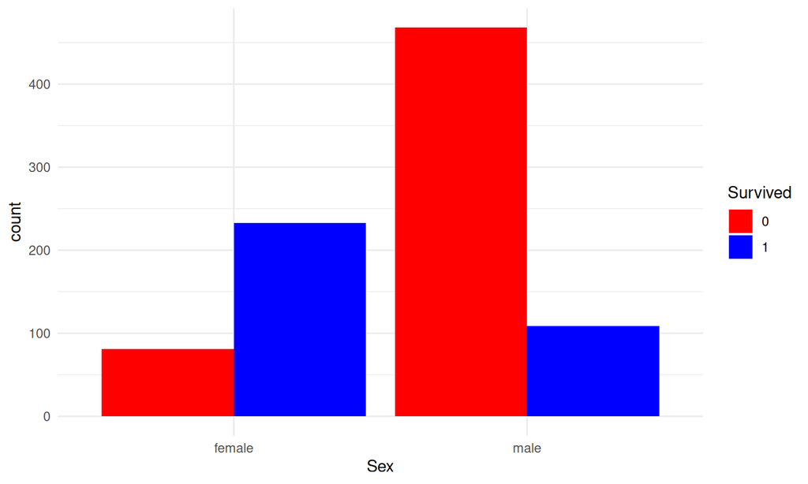

## Solving the problem

## Data preprocessing

- Missing values:
  - Dropped irrelevant columns
- Encoding - Sex + Embarked (categorical -> numeric)

## Comparison of classifiers before preprocessing

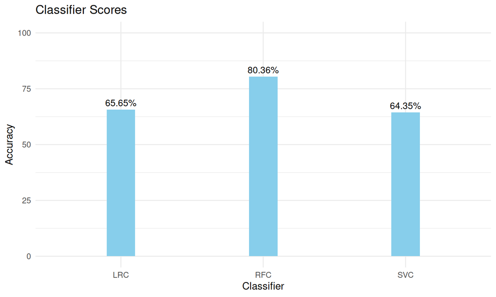

## Preprocessing techniques

- Standardization: `StandardScaler`

[output not shown]

## Feature Selection

- RFE (Recursive Feature Elimination) with LR, RFC
- Selected features:
  - for LR: **Pclass**, **Sex**, **Age**, **SibSp**

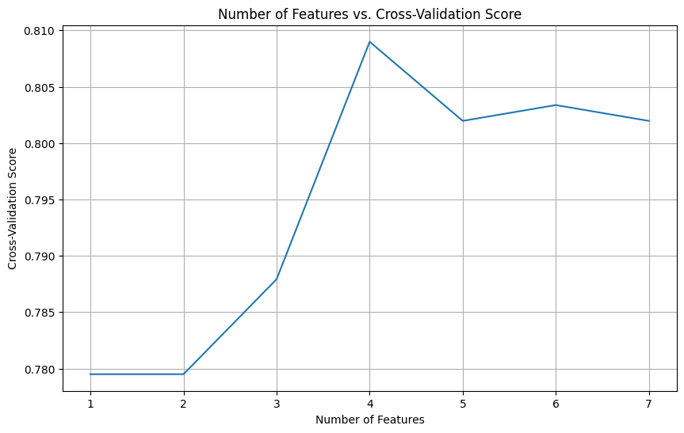

## Feature Selection

- RFE (Recursive Feature Elimination) with LR, RFC
- Selected features:
  - for RFC: **Pclass**, **Sex**, **Age**, **Fare**

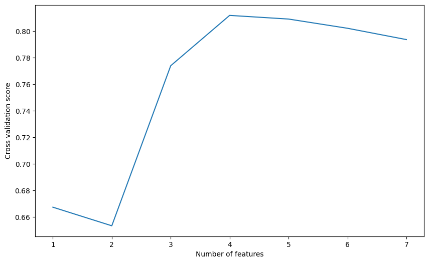

## Feature Selection

- RFE (Recursive Feature Elimination) with LR, RFC
- Selected features:
  - for LR (plot on the left): **Pclass**, **Sex**, **Age**, **SibSp**
  - for RFC (plot on the right): **Pclass**, **Sex**, **Age**, **Fare**

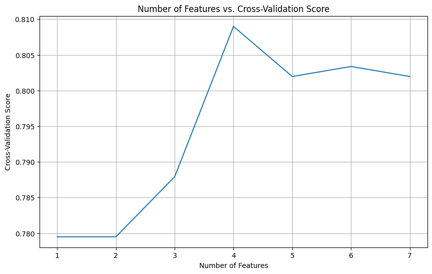

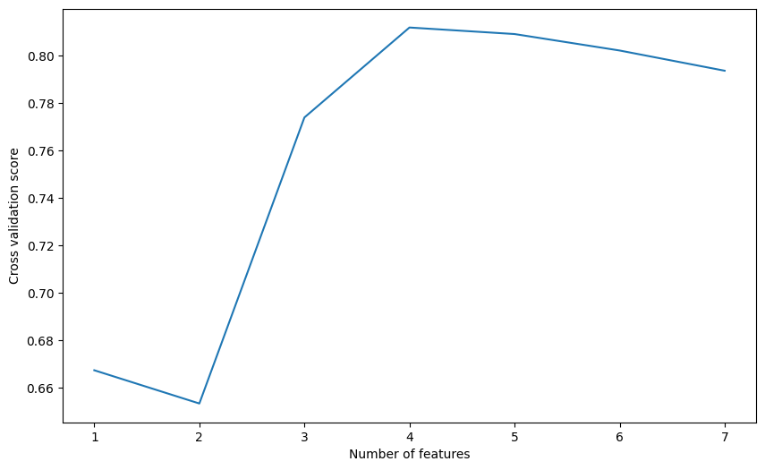

## Feature extraction

- PCA (Principal Component Analysis)

```
[[ 1.03979617, -0.8338755 ,  0.39574407, -0.124945  ],
    [-0.8159031 ,  1.9567542 ,  0.23809646, -0.0552459 ],
    [ 0.48443562,  0.35598023, -1.52130571, -0.51725331],
    ...,
    [-0.44638046,  1.59476638, -0.76656293,  1.20977618],
    [-0.94330883, -0.02518358,  0.51553682,  1.40835751],
    [ 0.03490097, -1.26169953, -0.25152961, -0.27004702]]
```

- Selected: **Pclass**, **Sex**, **Age**, **SibSp**

## Classifiers comparison after selecting and extracting features

- SVC, RFC, LR after actions

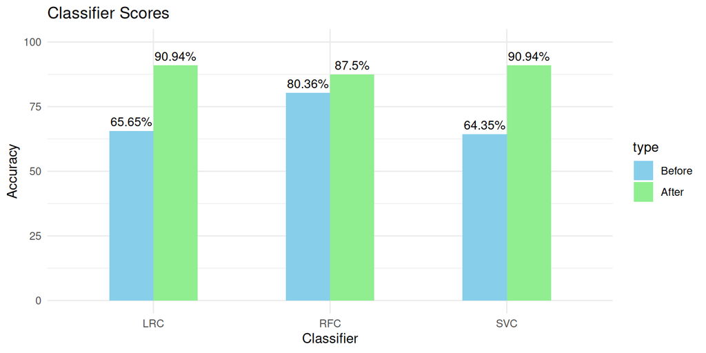

## Conclusion

- Data preprocessing significantly improved classifier accuracy.
- Feature selection techniques identified key predictors: Pclass, Sex, Age, and SibSp.
- Feature extraction via PCA simplified models while retaining essential information.
- Post-preprocessing, classifiers (SVC, RFC, LR) demonstrated improved performance.